# Generating Various Synthetic Datasets

Author

Aditi Gajjar

Published

February 8, 2025

# Introduction

This vignette demonstrates how to use the functions from the `syntheticDatasets` package to generate various synthetic datasets. These datasets are suitable for different types of statistical and machine learning analyses. The functions covered in this vignette include:

1. `make_anova`
2. `make_regression`
3. `make_spiral`
4. `make_moons`
5. `make_four_square`
6. `make_classification`
7. `make_circles`
8. `make_blobs`

# 1. make_anova

The `make_anova` function generates synthetic data suitable for ANOVA (Analysis of Variance) testing. It creates a dataset with a specified number of groups, samples per group, and features, adding an optional group effect to simulate between-group differences.

## Parameters

- **n_groups**: Number of groups to generate data for. Default is 3.
- **n_samples_per_group**: Number of samples per group. Default is 100.
- **n_features**: Total number of features. Default is 100.
- **n_informative**: Number of informative features. Influences the regression target. Default is 10.
- **bias**: Bias term in the underlying linear model. Default is 0.0.
- **noise**: Standard deviation of the Gaussian noise applied to the output. Default is 5.0.
- **shuffle**: Logical, indicating whether to shuffle the samples. Default is TRUE.
- **coef**: If TRUE, the coefficients of the underlying linear model are returned. Default is FALSE.
- **random_state**: Integer, the seed used by the random number generator for reproducibility. Can be NULL. Default is NULL.
- **effective_rank**: The approximate number of singular vectors required to explain most of the input data by linear combinations. Relevant for ‘make_regression’. Default is NULL.
- **tail_strength**: The relative importance of the fat noisy tail of the singular values profile if ‘effective_rank’ is not NULL. Default is 0.5.
- **group_effect**: The effect size to be added to each group to simulate between-group differences. Default is 10.
- **plot**: Logical, indicating whether to plot the dataset. Default is FALSE.

## Example Usage

```r
library(syntheticDatasets)

# Generate default ANOVA data
anova_data <- make_anova()
str(anova_data)
```

```
List of 3
 $ X          : num [1:300, 1:100] 1.302 -0.272 -1.002 -0.233 1.25 ...
 $ Y          : num [1:300] 29.64 31.58 41.85 4.57 29.52 ...
 $ GroupLabels: int [1:300] 3 3 3 1 3 3 3 1 3 2 ...
```

```r
# Generate ANOVA data with 5 groups, each with 50 samples
custom_anova_data <- make_anova(n_groups = 5, n_samples_per_group = 50)
str(custom_anova_data)
```

```
List of 3
 $ X          : num [1:250, 1:100] 1.226 1.15 -0.332 -0.927 -0.783 ...
 $ Y          : num [1:250] 7.58 11.54 8.82 42.54 15.67 ...
 $ GroupLabels: int [1:250] 1 2 1 4 2 3 1 3 1 2 ...
```

```r
# Apply group effects
group_effect_anova_data <- make_anova(n_groups = 3, n_samples_per_group = 100, group_effect = 20)
str(group_effect_anova_data)
```

```
List of 3
 $ X          : num [1:300, 1:100] 0.4805 -0.7082 -0.5524 -2.4177 -0.0934 ...
 $ Y          : num [1:300] 63 21.4 38.6 14.8 26.8 ...
 $ GroupLabels: int [1:300] 3 1 2 1 1 2 1 2 1 2 ...
```

```r
# Shuffle samples
shuffled_anova_data <- make_anova(n_groups = 3, n_samples_per_group = 100, shuffle = TRUE)
str(shuffled_anova_data)
```

```
List of 3
 $ X          : num [1:300, 1:100] -0.824 0.0407 0.4163 -2.6071 -0.5296 ...
 $ Y          : num [1:300] 7.94 28.95 3.46 12.65 27.04 ...
 $ GroupLabels: int [1:300] 1 3 1 2 3 3 2 2 3 3 ...
```

```r
shuffled_anova_data$Y
```

```
  [1]  7.9399302 28.9508525  3.4558111 12.6527126 27.0409543 32.1295883
  [7] 29.8577279 20.6868956 27.6597983 18.4109702 14.0682757 30.3850295
 [13] 22.3615820 22.9080214  4.1339960 39.6127877 30.3118730  2.9093542
 [19]  9.6167458 11.2546612 32.4172973  3.8660449 40.1407438 19.1277420
 [25] 26.5844331 17.2167099 17.4839931 18.7178052 27.8897038 16.8878609
 [31] 22.2951389  6.6119751 11.8533202 35.8834185 24.7208915 22.2541814
 [37] 14.2514216 30.3058964 25.5331758 12.2260308  1.9858907  5.0725964
 [43] 35.9022697 15.1598008  9.4672618 27.6495550 12.8108878 34.1097553
 [49] 18.2638337 22.5011113 30.0926257 34.3739941 25.3587083 25.6586638
 [55] 10.8531923 39.1735306 24.1407030 20.0614565 19.6158480 16.0391802
 [61] 19.7906249  9.9047740 34.8029379 19.4742164  7.9293032 15.8944814
 [67] 37.7851991 21.6980910 11.1841957 10.0614579 12.2077502 10.7633248
 [73] 31.5884948 26.9660222 43.1025750 13.9731298 25.1051156 11.0487272
 [79] 23.7336962 24.8943907  9.0524545 16.6923726 20.3036391  5.4714476
 [85]  9.8134153 18.0621464 19.1406780 25.8051675 37.7579897  8.7922807
```

[output cut: 35 more lines]

# 2. make_regression

The `make_regression` function generates a regression dataset suitable for testing linear regression models. It allows customization of the number of samples, features, informative features, targets, noise, and other parameters to simulate various regression scenarios.

## Parameters

- **n_samples**: Total number of samples to generate. Default is 100.
- **n_features**: Total number of features. Non-informative features are generated as noise. Default is 100.
- **n_informative**: Number of informative features, i.e., features actually used to build the linear model. Default is 10.
- **n_targets**: Number of targets (response variables) to generate. Default is 1.
- **bias**: Intercept term in the underlying linear model. Default is 0.0.
- **noise**: Standard deviation of Gaussian noise added to the output. Default is 0.0.
- **shuffle**: Logical, indicating whether to shuffle the samples. Default is TRUE.
- **coef**: Logical, indicates whether to return the coefficients of the underlying linear model along with the dataset. Default is FALSE.
- **random_state**: Integer, the seed used by the random number generator for reproducibility. Can be `NULL`. Default is `NULL`.
- **effective_rank**: The approximate number of singular vectors required to explain most of the input data by linear combinations. Relevant for simulating data with collinear features. Default is `NULL`.
- **tail_strength**: The relative importance of the fat noisy tail of the singular values profile if `effective_rank` is not `NULL`. Affects how quickly the importance of singular vectors falls off. Default is 0.5.
- **plot**: Logical, indicating whether to plot the dataset. Supported only for datasets with a single target. Default is FALSE.

## Example Usage

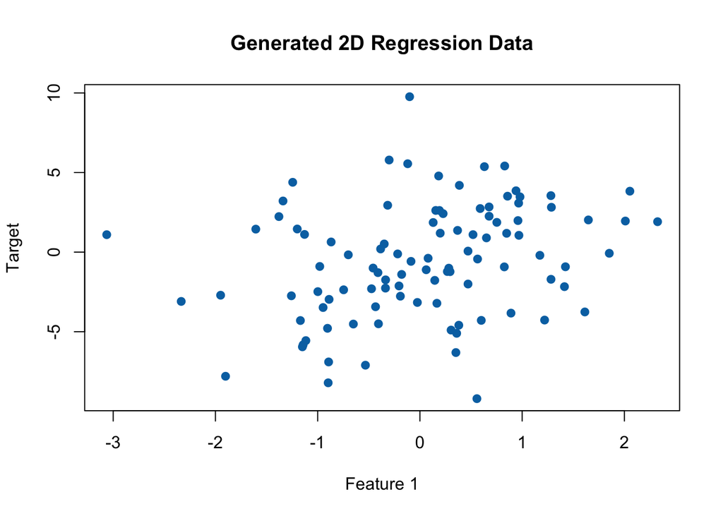

```r
# Generate a simple regression dataset and plot it
simple_regression <- make_regression(plot = TRUE)
```

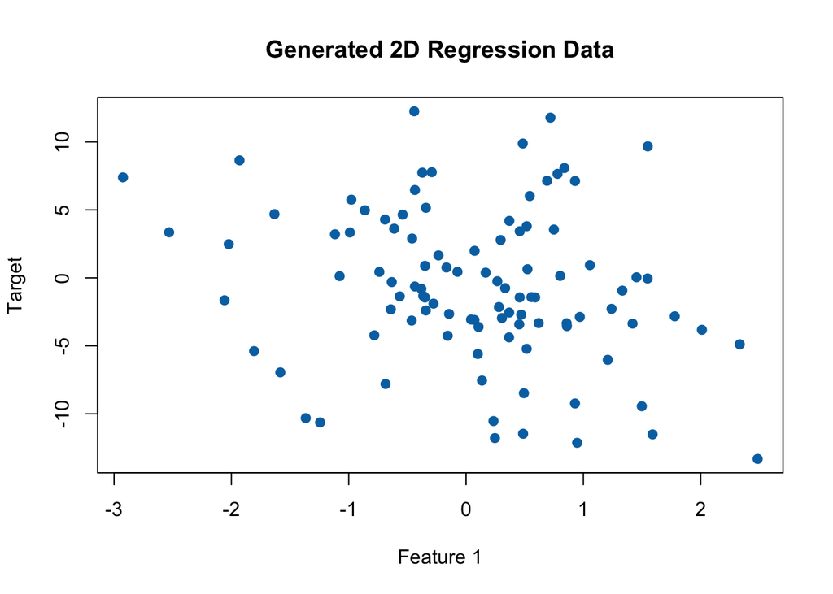

```r
# Generate a regression dataset with more informative features and plot it
informative_regression <- make_regression(n_features=200, n_informative=50, plot=TRUE)
```

```r
# Generate a multi-output regression dataset and plot it
multi_output_regression <- make_regression(n_targets=2, plot=TRUE)
```

# 3. make_spiral

The `make_spiral` function generates a two-dimensional spiral dataset, which is useful for testing clustering algorithms and visualizations.

## Example Usage

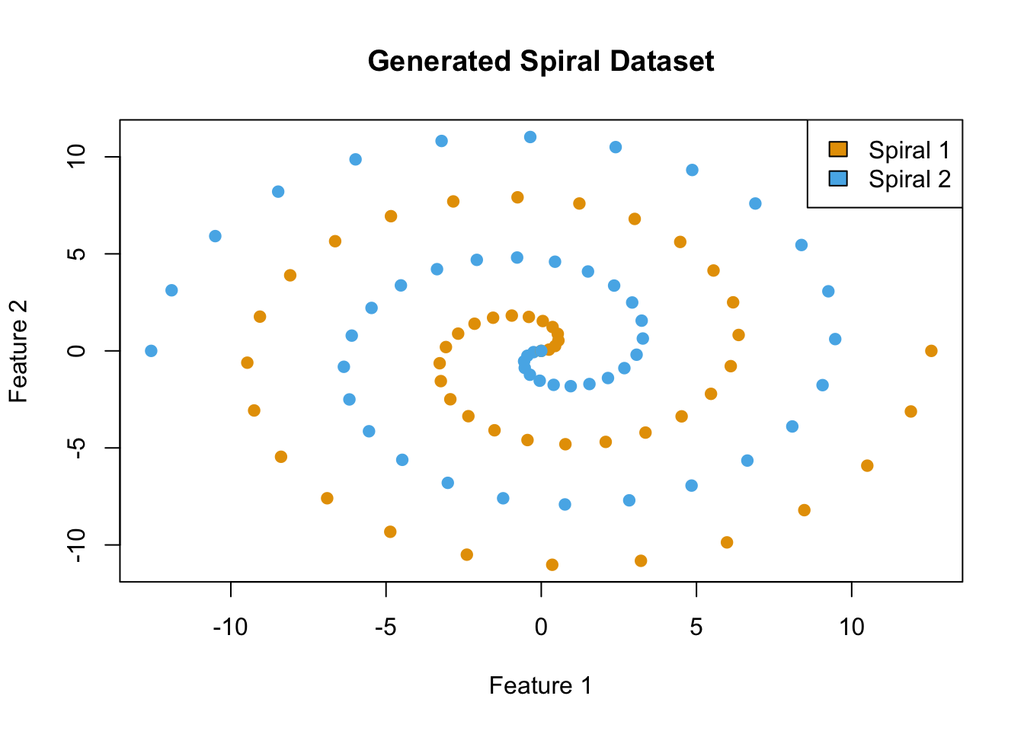

```r
# Generate a spiral dataset
spiral_data <- make_spiral(plot = T)
```

# 4. make_moons

The `make_moons` function generates a two-dimensional dataset with two interleaving half circles, commonly used for binary classification tasks.

## Example Usage

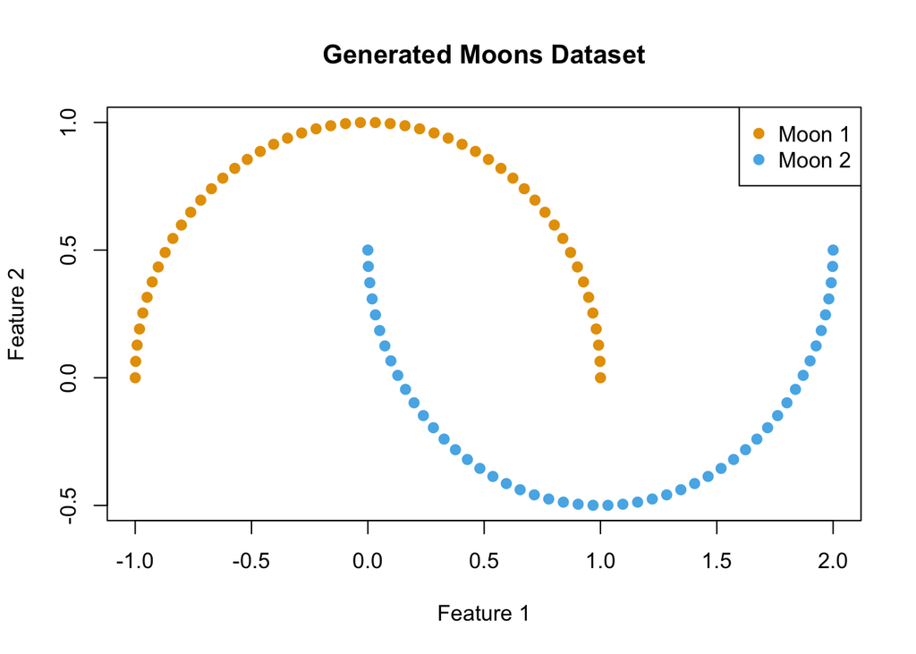

```r
# Generate a moons dataset
moons_data <- make_moons(plot=T)
```

# 5. make_four_square

The `make_four_square` function generates a two-dimensional dataset with four clusters, arranged in a square pattern.

## Example Usage

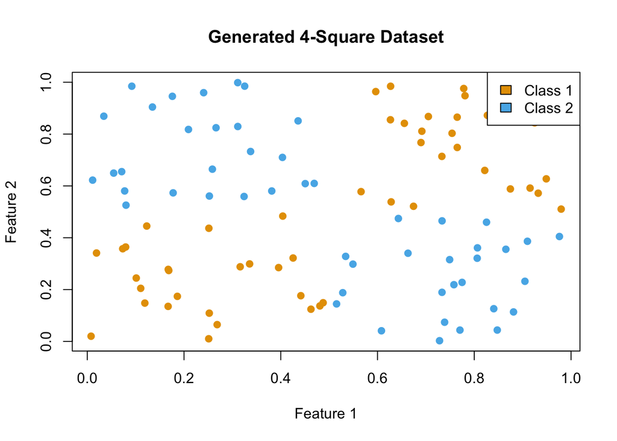

```r
four_square_data <- make_four_square(plot=T)
```

# 6. make_classification

The `make_classification` function generates a random multi-class classification problem.

## Example Usage

```r
# Generate a classification dataset
classification_data <- make_classification(plot=T)
```

[output not shown]

# 7. make_circles

The `make_circles` function generates a large circle containing a smaller circle in two dimensions.

## Example Usage

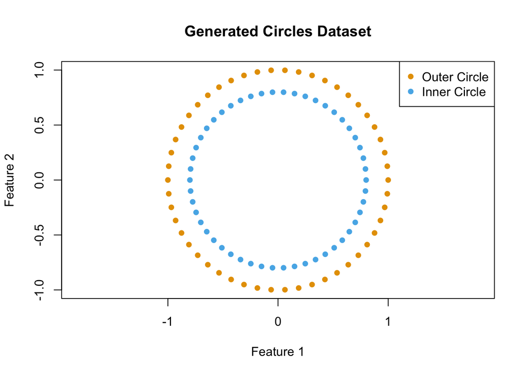

```r
# Generate a circles dataset
circles_data <- make_circles(plot=T)
```

# 8. make_blobs

The `make_blobs` function generates isotropic Gaussian blobs for clustering.

## Example Usage

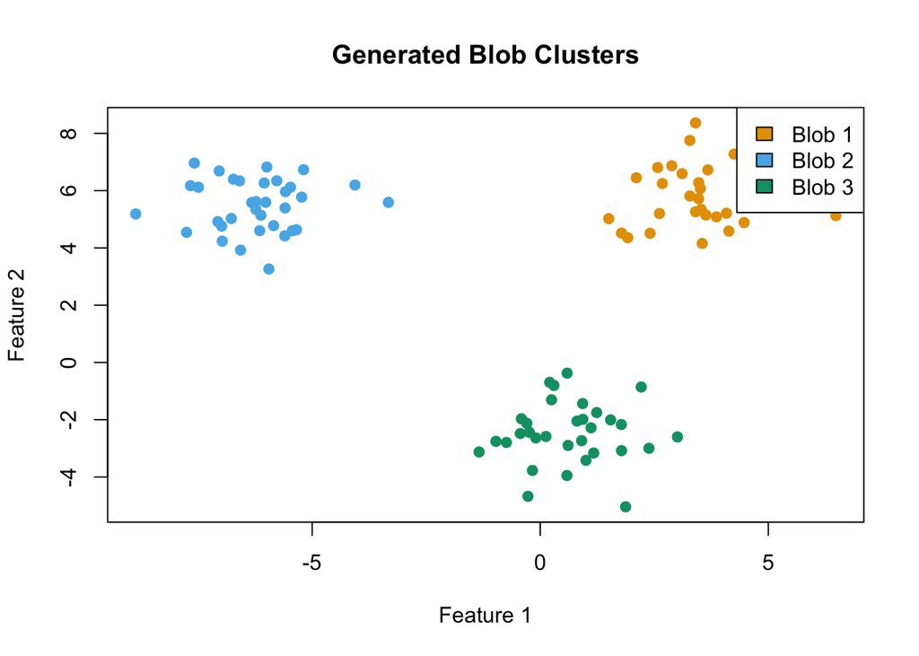

```r
# Generate a blobs dataset
blobs_data <- make_blobs(plot = T)
```

# Conclusion

The `syntheticDatasets` package provides a variety of functions to generate synthetic datasets for different types of analyses. These functions allow customization of various parameters to suit specific testing needs, making them valuable tools for statistical and machine learning research.

For more details on each function, refer to the respective documentation files.